# Some common uses of matplotlib

*refer to matplotlib's document*

## Brief Intro

According to region size

**Canvas>Artist>Figure>Axes>Axis**

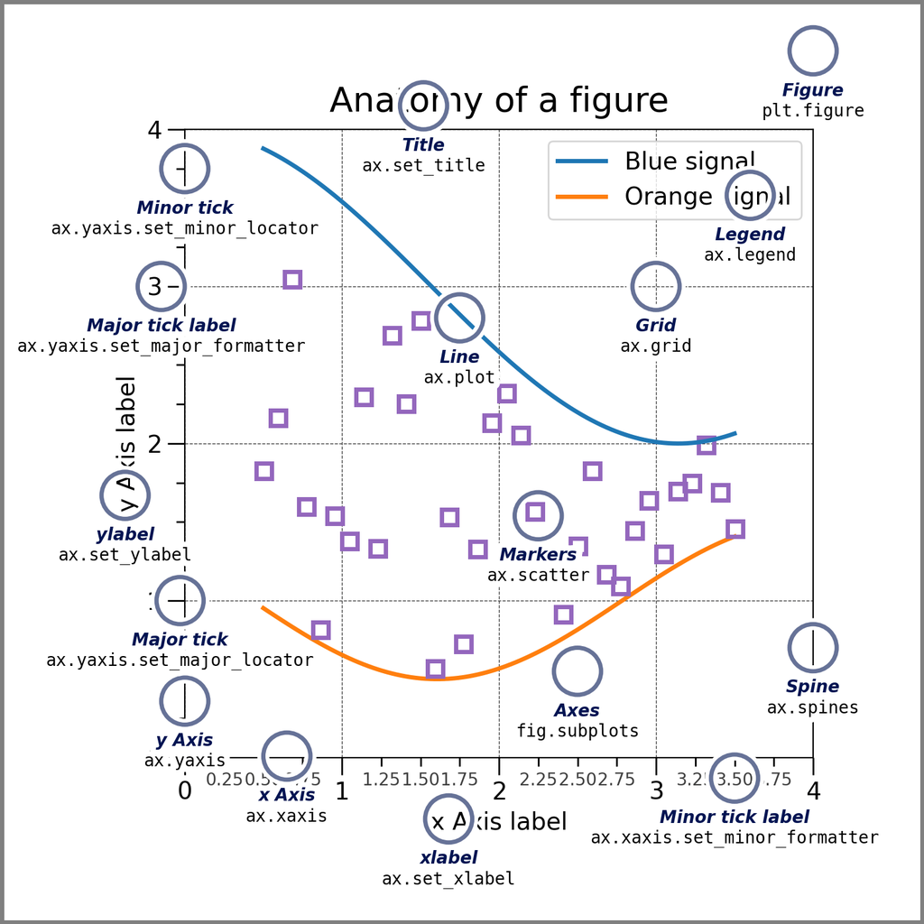

### Artist

Basically, everything visible on the Figure is an `Artist` (even `Figure`, `Axes`, and `Axis` objects). This includes Text objects, Line2D objects, collections objects, Patch objects, etc. When the Figure is rendered, all of the Artists are drawn to the **canvas**. Most `Artists` are tied to an `Axes`; such an `Artist` cannot be shared by multiple Axes, or moved from one to another.

### Figure

The whole figure. The Figure keeps track of all the child `Axes`, a group of 'special' Artists (titles, figure legends, colorbars, etc), and even nested subfigures.

### Axes

An Axes is an Artist attached to a Figure that contains a region for plotting data, and usually includes two (or three in the case of 3D) `Axis` objects (be aware of the difference between **Axes** and **Axis**) that provide ticks and tick labels to provide scales for the data in the Axes. Each `Axes` also has a title (set via `set_title()`), an x-label (set via `set_xlabel()`), and a y-label set via `set_ylabel()`).

The `Axes` class and its member functions are the primary entry point to working with the OOP interface, and have most of the plotting methods defined on them (e.g. ax.plot(), shown above, uses the `plot` method)

### Axis

These objects set the scale and limits and generate ticks (the marks on the Axis) and ticklabels (strings labeling the ticks). The location of the ticks is determined by a `Locator` object and the ticklabel strings are formatted by a `Formatter`. The combination of the correct `Locator` and `Formatter` gives very fine control over the tick locations and labels.

```python
# %matplotlib inline
import matplotlib as mpl
import matplotlib.pyplot as plt
import numpy as np
```

## Two coding STYLEs

- Explicitly create Figures and Axes, and call methods on them (the "object-oriented (OO) style").
- Rely on pyplot to implicitly create and manage the Figures and Axes, and use pyplot functions for plotting.

### OO-style

A Figure in matplotlib is divided into two different objects.

- Figure object
- Axes object
1. A Figure object can contain one or more axes objects. One axes represents one plot inside figure. In this tutorial we will be working with the axes object directly for all kinds of plotting.
2. One or more axes objects are required to get us started with plotting. There are more then one ways an axes object can be obtained. We will start with the add_subplot() method and later will explore other ways.

#### The Figure Object & The Axes Object

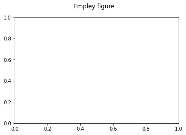

```python
fig = plt.figure()
fig.suptitle("Empley figure") # figure object
ax = fig.add_subplot(1,1,1) # axes object
plt.show()
# print(type(fig))
```

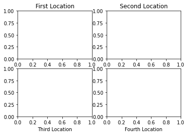

```python
## Example1.1 add_subplot
fig = plt.figure()

# Generate a grid of 2x2 subplots and get
# axes object for 1st location
ax1 = fig.add_subplot(2,2,1)
ax1.set_title('First Location')

# Get the axes object for subplot at 2nd
# location
ax2 = fig.add_subplot(2,2,2)
ax2.set_title('Second Location')

# Get the axes object for subplot at 3rd
# location
ax3 = fig.add_subplot(2,2,3)
ax3.set_xlabel('Third Location')

# Get the axes object for subplot at 4th
# location
ax4 = fig.add_subplot(2,2,4)
ax4.set_xlabel('Fourth Location')

# Display
plt.show()
```

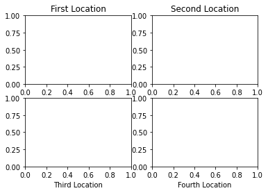

```python
fig, arr_ax = plt.subplots(2, 2)

# Generate a grid of 2x2 subplots and get
# axes object for 1st location
arr_ax[0,0].set_title('First Location')

# Get the axes object for subplot at 2nd
# location
arr_ax[0,1].set_title('Second Location')

# Get the axes object for subplot at 3rd
# location
arr_ax[1,0].set_xlabel('Third Location')

# Get the axes object for subplot at 4th
# location
arr_ax[1,1].set_xlabel('Fourth Location')

plt.show()
```

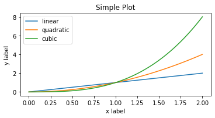

```python
## Example1.2: With the returned objects of plt.subplots
x = np.linspace(0, 2, 100)  # Sample data.

# Note that even in the OO-style, we use `.pyplot.figure` to create the Figure.
fig, ax = plt.subplots(figsize=(5, 2.7), layout='constrained')
ax.plot(x, x, label='linear')  # Plot some data on the axes.
ax.plot(x, x**2, label='quadratic')  # Plot more data on the axes...
ax.plot(x, x**3, label='cubic')  # ... and some more.
ax.set_xlabel('x label')  # Add an x-label to the axes.
ax.set_ylabel('y label')  # Add a y-label to the axes.
ax.set_title("Simple Plot")  # Add a title to the axes.
ax.legend()  # Add a legend.
```

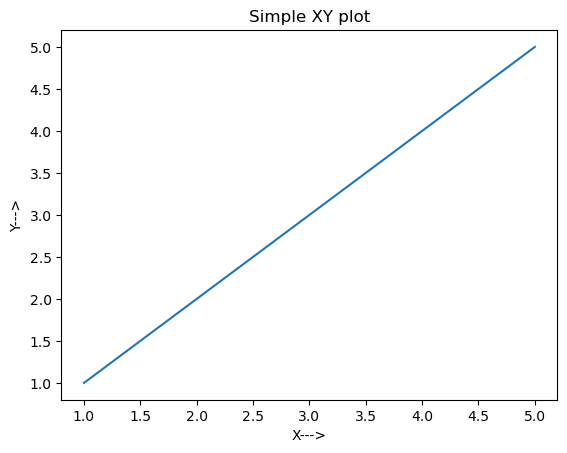

```python
## Example2 plot
# Generate data for plots
x = [1, 2, 3, 4, 5]
y = x

# Get an empty figure
fig1 = plt.figure()

# Get the axes instance at 1st location in 1x1 grid
ax = fig1.add_subplot(1,1,1)

# Generate the plot
ax.plot(x, y)

# Set labels for x and y axis
ax.set_xlabel('X--->')
ax.set_ylabel('Y--->')

# Set title for the plot
ax.set_title('Simple XY plot')

# Display the figure
plt.show()
```

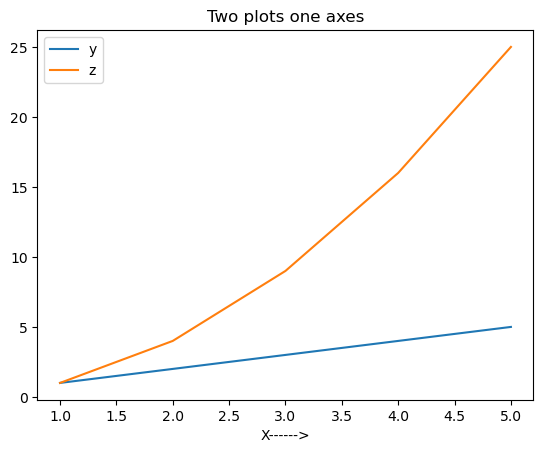

```python
## Example3 Multiple Graphs In Same Plot
# Function to get the square of each element in the list
def list_square(a_list):
    return [element**2 for element in a_list]

# Multiple plot in same subplot window
# plot y = x and z = x^2 in the same subplot window
fig2 = plt.figure()

x = [1, 2, 3, 4, 5]
y = x
z = list_square(x)

# Get the axes instance
ax = fig2.add_subplot(1,1,1)

# Plot y vs x as well as z vs x. label will be used by ax.legend() method to generate a legend automatically
ax.plot(x, y, label='y')
ax.plot(x, z, label='z')
ax.set_xlabel("X------>")

# Generate legend
ax.legend()

# Set title
ax.set_title('Two plots one axes')

# Display
plt.show()
```

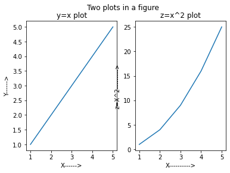

```python
## Example4: Two Plots In A Figure
# Function to get the square of each element in the list
def list_square(a_list):
    return [element**2 for element in a_list]

# Multiple subplots in same figure
fig3 = plt.figure()
x = [1, 2, 3, 4, 5]
y = x
z = list_square(x)

# Divide the figure into 1 row 2 column grid and get the
# axes object for the first column
ax1 = fig3.add_subplot(1,2,1)

# plot y = x on axes instance 1
ax1.plot(x, y)

# set x and y axis labels
ax1.set_xlabel('X------>')
ax1.set_ylabel('Y------>')
ax1.set_title('y=x plot')

# Get second axes instance in the second column of the 1x2 grid
ax2 = fig3.add_subplot(1,2,2)

# plot z = x^2
ax2.plot(x, z)
ax2.set_xlabel('X---------->')
ax2.set_ylabel('z=X^2--------->')
ax2.set_title('z=x^2 plot')

# Generate the title for the Figure. Note that this is different then the title for individual plots
plt.suptitle("Two plots in a figure")
plt.show()
```

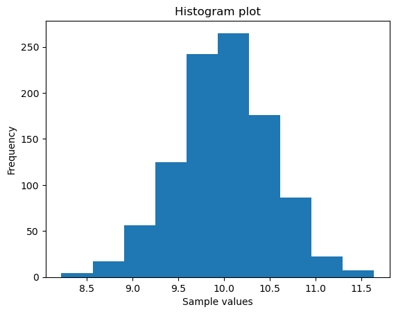

```python
## Example5: Histogram Plots
# Generate 1000 numbers from gaussian sample
mean = 10
std = 0.5
num_samples = 1000
samples = np.random.normal(mean, std, num_samples)

# Get an instance of Figure object
fig = plt.figure()
ax = fig.add_subplot(1,1,1)

# Generate histogram plot
ax.hist(samples)
ax.set_xlabel('Sample values')
ax.set_ylabel('Frequency')
ax.set_title('Histogram plot')

plt.show()
```

### Pyplot-style

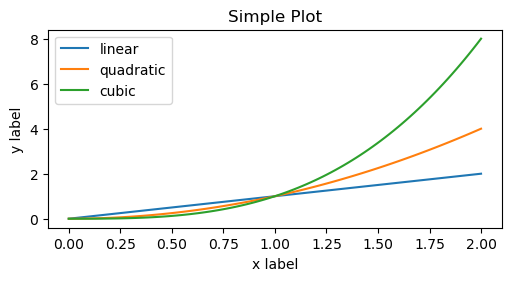

```python
x = np.linspace(0, 2, 100)  # Sample data.

plt.figure(figsize=(5, 2.7), layout='constrained')
plt.plot(x, x, label='linear')  # Plot some data on the (implicit) axes.
plt.plot(x, x**2, label='quadratic')  # etc.
plt.plot(x, x**3, label='cubic')
plt.xlabel('x label')
plt.ylabel('y label')
plt.title("Simple Plot")
plt.legend()
```

*Notice:Matplotlib's documentation and examples use both the OO and the pyplot styles. In general, we suggest using the **OO style**, particularly for complicated plots, and functions and scripts that are intended to be reused as part of a larger project. However, the pyplot style can be very convenient for quick interactive work.*

## Pyplot Introduction

Each `pyplot` function makes some change to a figure: e.g., creates a figure, creates a plotting area in a figure, plots some lines in a plotting area, decorates the plot with labels, etc.

In `matplotlib.pyplot` various states are preserved across function calls, so that it keeps track of things like the current figure and plotting area, and the plotting functions are directed to the current axes

### Single figure or multiple figures

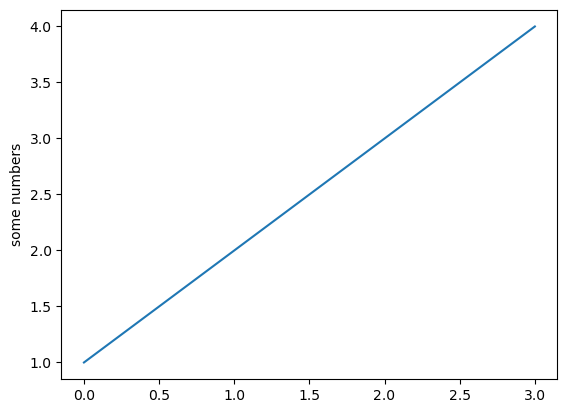

```python
plt.plot([1, 2, 3, 4])
plt.ylabel('some numbers')
plt.show()
```

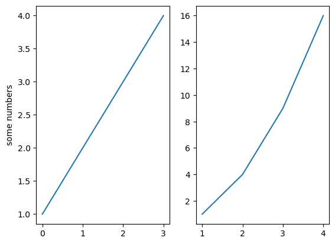

```python
plt.figure()
plt.subplot(121)
plt.plot([1, 2, 3, 4])
plt.ylabel('some numbers')

plt.subplot(122)
plt.plot([1, 2, 3, 4], [1, 4, 9, 16])

plt.show()
```

### Formatting the style of your plot

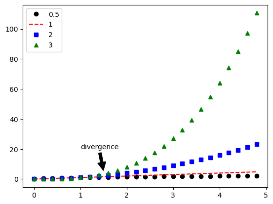

```python
t = np.arange(0., 5., 0.2)

# black dot,red dashes, blue squares and green triangles
plt.plot(t, t**0.5, 'ko',t, t, 'r--', t, t**2, 'bs', t, t**3, 'g^')

# provides helper functionality to make annotations easy
plt.annotate('divergence', xy=(1.5, 5), xytext=(1, 20),
             arrowprops=dict(facecolor='black', shrink=0.05),
             )

plt.legend(['0.5','1','2','3'])
# default--best; you can also choose 'upper left', 'upper right', 'lower left', 'lower right' place the legend at the corresponding corner of the axes.

plt.show()
```

### Plotting with categorical variables

It is also possible to create a plot using categorical variables. Matplotlib allows you to pass categorical variables directly to many plotting functions

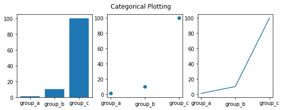

```python
names = ['group_a', 'group_b', 'group_c']
values = [1, 10, 100]

plt.figure(figsize=(9, 3))# init size

plt.subplot(131)
plt.bar(names, values)
plt.subplot(132)
plt.scatter(names, values)
plt.subplot(133)
plt.plot(names, values)
plt.suptitle('Categorical Plotting')
plt.show()
```

### Share axes

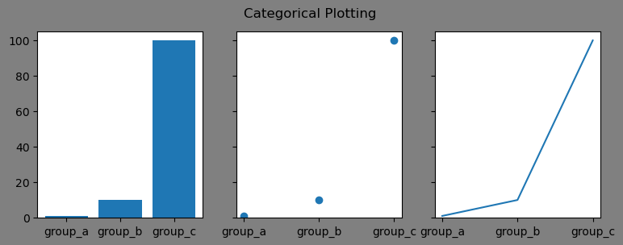

```python
# use share axe
names = ['group_a', 'group_b', 'group_c']
values = [1, 10, 100]

# init size,set sharey enable,
fig,[ax0,ax1,ax2]=plt.subplots(1,3,sharey=True,facecolor='grey',figsize=(9, 3))

ax0.bar(names, values)
ax1.scatter(names, values)
ax2.plot(names, values)
plt.suptitle('Categorical Plotting')
plt.show()
```

### logarithmic and some nonlinear axes

`matplotlib.pyplot` supports not only linear axis scales, but also logarithmic and logit scales. This is commonly used if data spans many orders of magnitude

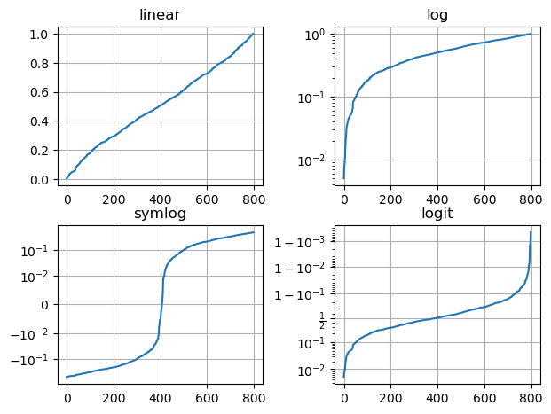

```python
# Fixing random state for reproducibility
np.random.seed(19680801)

# make up some data in the open interval (0, 1)
y = np.random.normal(loc=0.5, scale=0.4, size=1000)
y = y[(y > 0) & (y < 1)]
y.sort()
x = np.arange(len(y))

# plot with various axes scales
plt.figure()

# linear
plt.subplot(221)
plt.plot(x, y)
plt.yscale('linear')
plt.title('linear')
plt.grid(True)

# log
plt.subplot(222)
plt.plot(x, y)
plt.yscale('log')
plt.title('log')
plt.grid(True)

# symmetric log
plt.subplot(223)
plt.plot(x, y - y.mean())
plt.yscale('symlog', linthresh=0.01)
plt.title('symlog')
plt.grid(True)

# logit
plt.subplot(224)
plt.plot(x, y)
plt.yscale('logit')
plt.title('logit')
plt.grid(True)
# Adjust the subplot layout, because the logit one may take more space
# than usual, due to y-tick labels like "1 - 10^{-3}"
plt.subplots_adjust(top=0.92, bottom=0.08, left=0.10, right=0.95, hspace=0.25,
                    wspace=0.35)

plt.show()
```

*More details and examples you can find in https://matplotlib.org/stable/api/_as_gen/matplotlib.lines.Line2D.html#matplotlib.lines.Line2D*